# Visuals for Groups Comparison

Muhammad Hilmi Abdul Majid

## Introduction

In the previous topics, we have looked at some visuals and graphs that can be used to visualize and display the distributions of data. We have so far only focused on a single group only. In this topic, we will look at some visuals that can be used to make comparison between groups, where we have two or more groups and we want to display the differences or similarity between them.

We load the `ggplot2` and `dplyr` packages as usual first.

```r
library(ggplot2)
library(dplyr)
```

Additionally, we will use the `mpg` dataset from `ggplot2` package. You can read through its help page by running `?mpg` or `help(mpg)` after loading the `ggplot2` package. We will modify the dataset first to group all the automatic transmissions into one value and all manual transmissions into one value.

```r
# Mutate the trans column from mpg
# If the value in the original trans start with 'a', change it to 'auto'
# Otherwise change it to 'manual'
mpg2 <- mpg %>%
  mutate(trans=ifelse(substring(trans,1,1) == "a", "auto", "manual"))
```

## Faceting

One of the most used method to make group comparison is to use faceting as we have demonstrated in a previous topic. As mentioned in the earlier topic, facets are used to split data into groups or subsets and the graph or visual will be drawn for each of the groups.

To use facets, we simply add the function `facet_wrap()` or `facet_grid` in the chain. The `facet_wrap()` uses formula object as the argument and produces plot based on the formula.

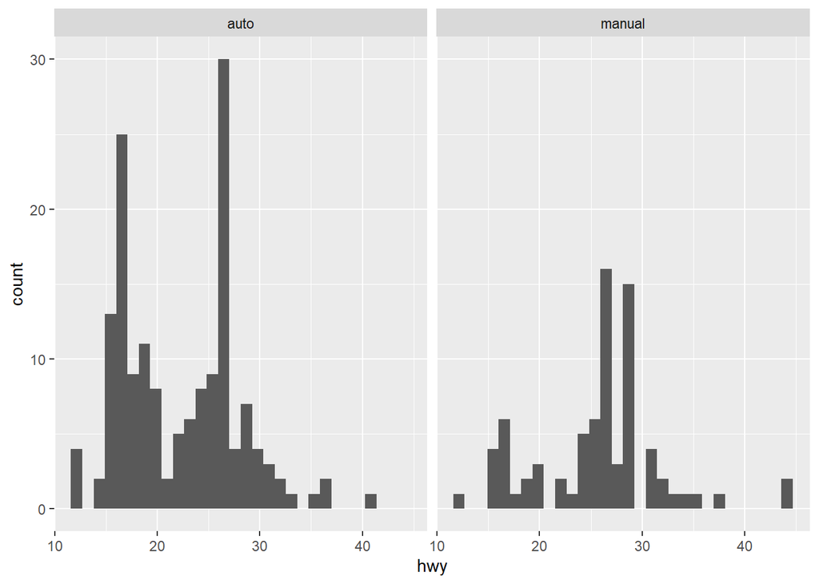

```r
# Specify the data and mapping
ggplot(data=mpg2, mapping=aes(x=hwy)) +

  # Draw histogram
  geom_histogram() +

  # Use facet that depends on trans
  facet_wrap(~trans)
```

We can specify the number of columns or rows that we want by adding the argument `ncol` and `nrow` in the `facet_wrap()` function. When making comparison using histogram in this example, it is better to use the same x-axis.

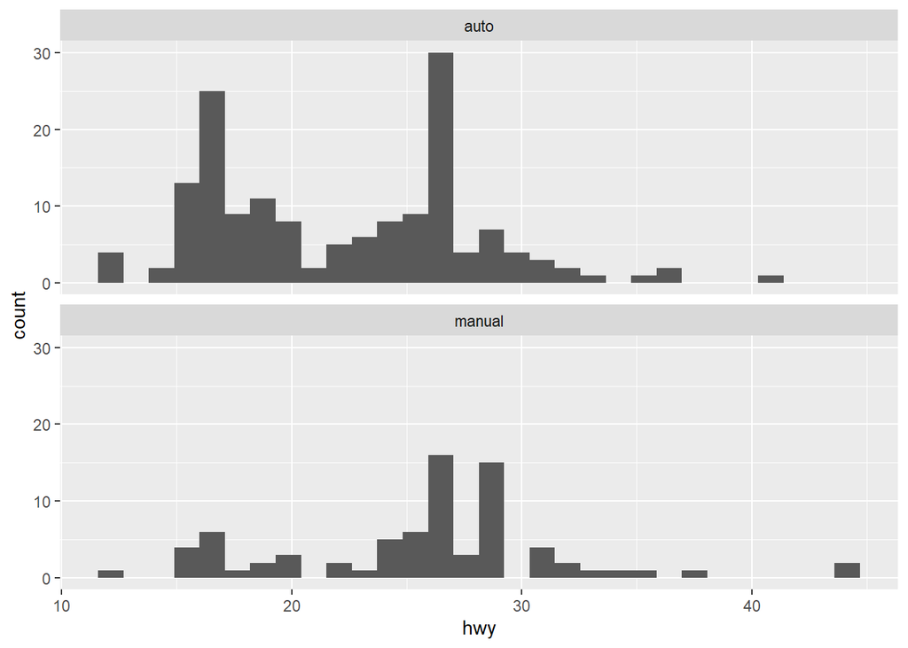

```r
# Specify the data and mapping
ggplot(data=mpg2, mapping=aes(x=hwy)) +

  # Draw histogram
  geom_histogram() +

  # Use facet that depends on trans with 1 column
  facet_wrap(~trans, ncol=1)
```

It seems that we have more cars with automatic transmission than manual transmission, and both transmissions exhibit bimodal distribution with modes around 26 highway mpg (miles per gallon) and around 16 highway mpg.

On the other hand, `facet_grid()` creates a grid-like output where we can specify the variables used for rows and columns. We can specify the variables used for rows and columns using `rows` and `cols` argument in `facet_grid()`. When specifying the variables, use `vars()` function to call the variable names.

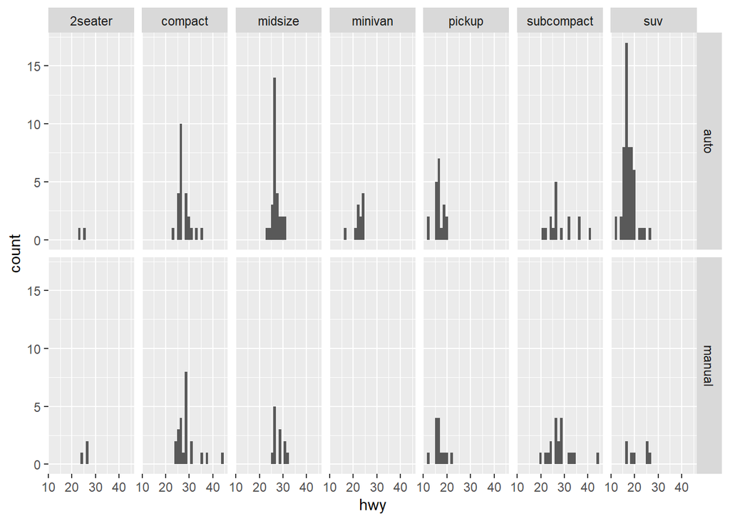

```r
# Specify the data and mapping
ggplot(data=mpg2, mapping=aes(x=hwy)) +

  # Draw histogram
  geom_histogram() +

  # Use facet on a grid where the rows are trans and columns are class
  facet_grid(rows=vars(trans), cols=vars(class))
```

The `facet_grid()` is more useful than `facet_wrap()` when we want to compare for more than one group variables. The similar plot can be produced using `facet_wrap()` as below.

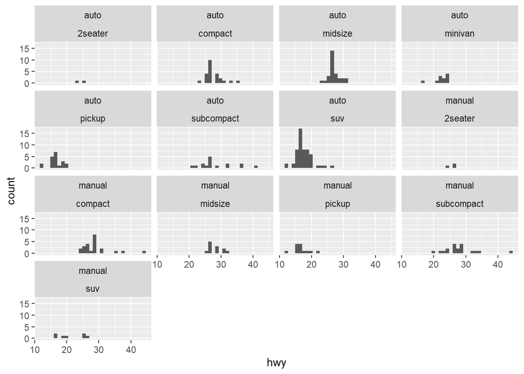

```r
# Specify the data and mapping
ggplot(data=mpg2, mapping=aes(x=hwy)) +

  # Draw histogram
  geom_histogram() +

  # Use facet that depends on trans and class
  facet_wrap(~trans+class)
```

## Comparing Distributions between Groups

When making comparison for the data distributions between different groups, we can continue using the visuals we used in previous topic to visualize data distribution. However, we can make changes to the plots to add elements to show visuals for different groups.

### Different forms of bar charts

We will first look at the different forms of bar charts that can be used when we have more than one group. These bar charts are especially useful when we have categorical variable and want to make comparison between groups.

#### Stacked bar chart

The stacked bar chart is an extension of the bar chart where the the grouping is shown visually on the same bar, stacked vertically. We can use the `fill` argument in the `aes()` function to show different filling colors for different groups. We can also set `position="stack"` in the `geom_bar()` function to produce a stacked bar chart but this is not necessary as it is the default position.

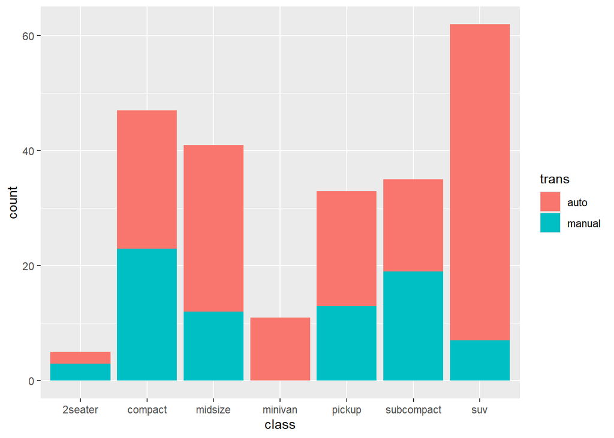

```r
# Specify the data and mapping, fill the bars accoring to trans
ggplot(data=mpg2, mapping=aes(x=class, fill=trans)) +

  # Draw bar chart, position different classes in stacks
  geom_bar(position="stack")
```

From the chart above, we can see that SUV is the most common vehicles in the dataset, and the 2-seater is the least common vehicles. We can also see that for SUV, most of them have automatic transmission. Additionally, we can see that all minivans are automatic transmission vehicles.

#### Grouped bar chart

The grouped bar chart is similar to the stacked bar chart, except different bars are plotted for the different groups. We can create a grouped bar chart by using the `fill` argument in the `aes()` mapping and use `position="dodge"` or `position=position_dodge()`in `geom_bar()`.

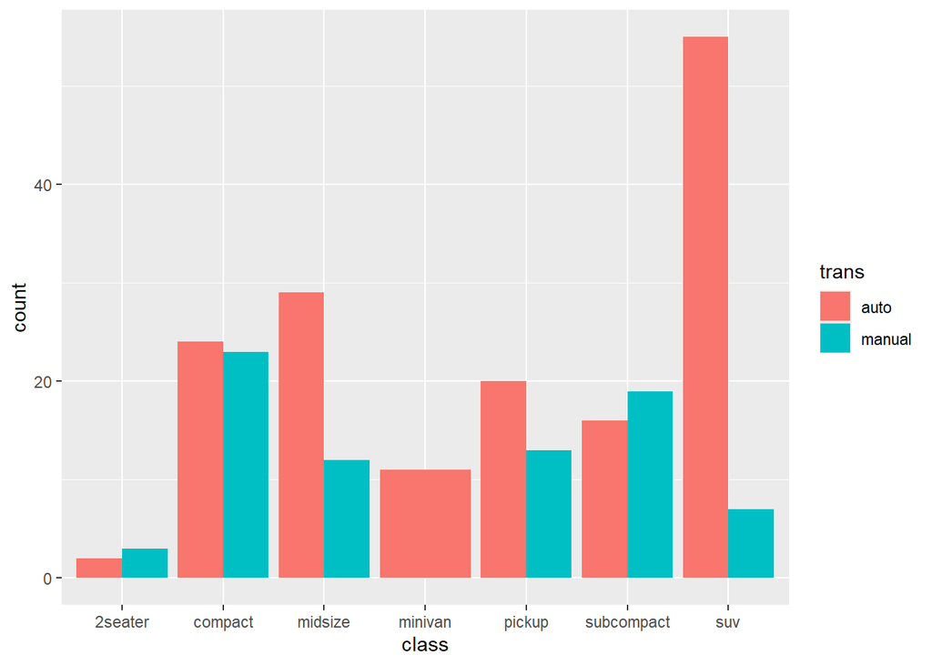

```r
# Specify the data and mapping, fill the bars accoring to trans
ggplot(data=mpg2, mapping=aes(x=class, fill=trans)) +

  # Draw bar chart, position different classes side-by-side
  geom_bar(position="dodge")
```

Notice that since there are no manual transmission for minivan, the width of the bar for minivan is doubled. If want to maintain the same width for all of them, we can use `position=position_dodge(preseve="single")` in `geom_bar()`.

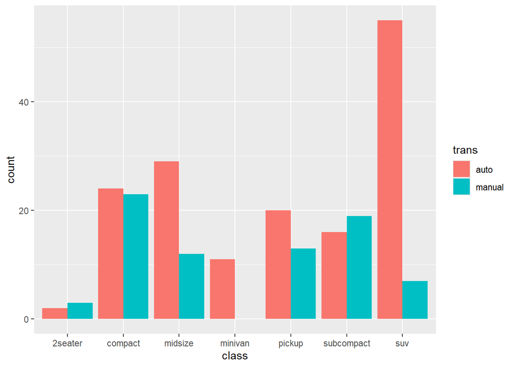

```r
# Specify the data and mapping, fill the bars accoring to trans
ggplot(data=mpg2, mapping=aes(x=class, fill=trans)) +

  # Draw bar chart
  # Position different classes side-by-side, make the width be of single element
  geom_bar(position=position_dodge(preserve="single"))
```

#### Segmented bar chart

The segmented bar chart, also called the 100% bar chart, is another form of bar chart where the y-axis is set to be 100% instead of count of observations as we have previously seen. It is used mainly to compare the proportions of data, or if we have a likert scale for the data.

To draw the segmented bar chart, we use `fill` argument in the `aes()` together with `position="fill"` in `geom_bar()`.

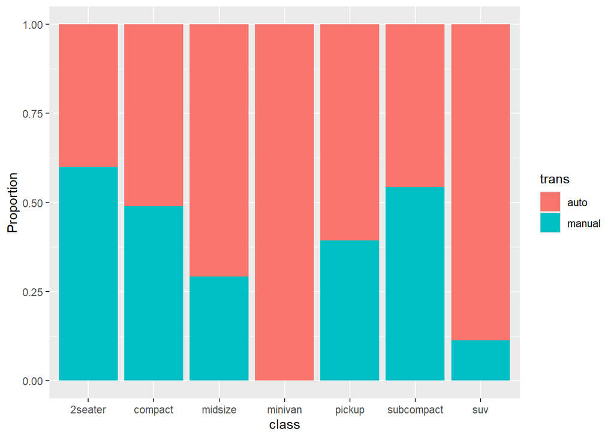

```r
# Specify the data and mapping, fill the bars accoring to trans
ggplot(data=mpg2, mapping=aes(x=class, fill=trans)) +

  # Draw bar chart, position different classes in stacks with constant heights
  geom_bar(position="fill") +

  # Change the y-axis label
  labs(y="Proportion")
```

#### Reordering groups and labels

By default, ggplot2 arrange the x-axis using the class or group name alphabetically. You can use the `factor()` function in the `aes()` mapping to reorder categories, both for the x-axis and fill label. Note that if `factor` is used, you might need to use `labs()` to specify the x-axis labels or fill legends.

When using `factor()`, you have to specify the variable you want to use, the order using `levels` argument, and the labels using `labels` argument in the `factor()` function. If `labels()` is not specified, it will use the levels as the labels.

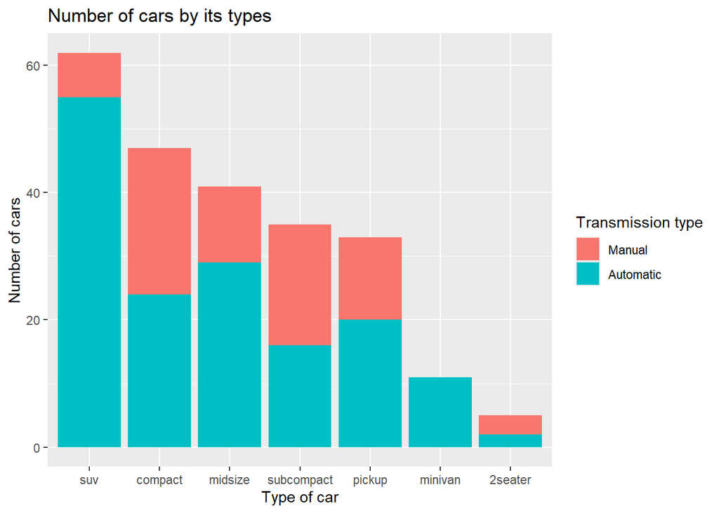

```r
# Specify the data and mapping
# Use x-axis according to the specified order
# Use fill according to the specified order and labels
ggplot(data=mpg2, mapping=aes(x=factor(class,
                                       levels=c("suv", "compact",
                                               "midsize", "subcompact",
                                               "pickup", "minivan", "2seater")),
                              fill=factor(trans,
                                          levels=c("manual", "auto"),
                                          labels=c("Manual", "Automatic")))) +

  # Draw a bar chart
  geom_bar() +

  # Change the x and y-axes label and fill legend
  labs(x="Type of car", y="Number of cars", fill="Transmission type",
       title="Number of cars by its types")
```

### Grouped boxplots and violin plots

The following visuals and charts that we will look at will focus more when we have quantitative variables or values for different groups. The first one we will look at are the grouped boxplots and violin plots.

In the previous topic, we have looked into boxplots and violin plots, but focused just for one group of data. To use boxplots to compare distribution of multiple groups, we simply use both the `x` and `y` arguments in the `aes()` mapping.

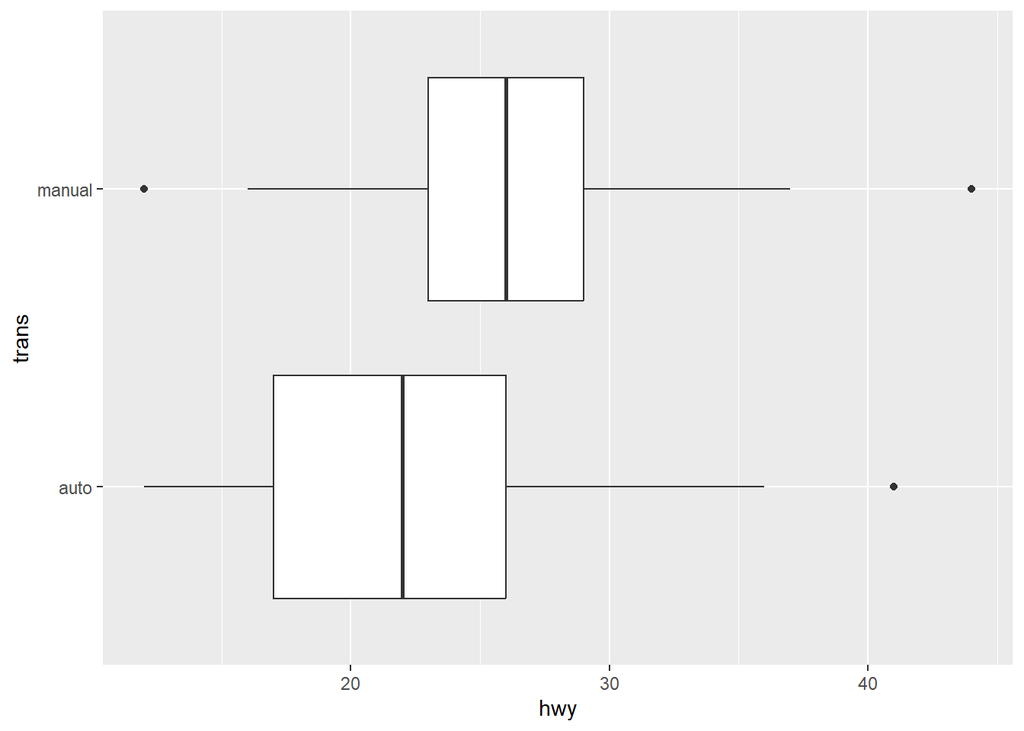

```r
# Specify the data and mapping
ggplot(data=mpg2, mapping=aes(x=hwy, y=trans)) +

  # Draw boxplots
  geom_boxplot()
```

Here we can see that in general, manual transmission has higher highway mpg compared to automatic transmission. We can also see some outliers that exist in the data.

Note that the `x` and `y` arguments used in `aes()` determine the orientation of the boxplot. If `x` is a quantitative variable and `y` is a categorical variable, then we will have a horizontal boxplot as above. However, if it is the other way around, then we will have a vertical boxplot.

We can do the similar thing using the violin plot.

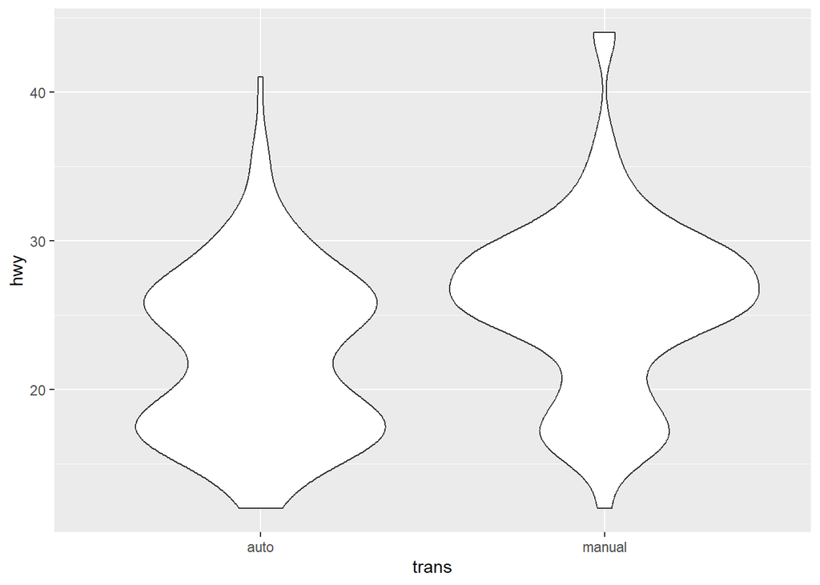

```r
# Specify the data and mapping
ggplot(data=mpg2, mapping=aes(y=hwy, x=trans)) +

  # Draw violin plots
  geom_violin()
```

For boxplots and violin plots, it is recommended to add jitters to display the data instead of relying on summarization.

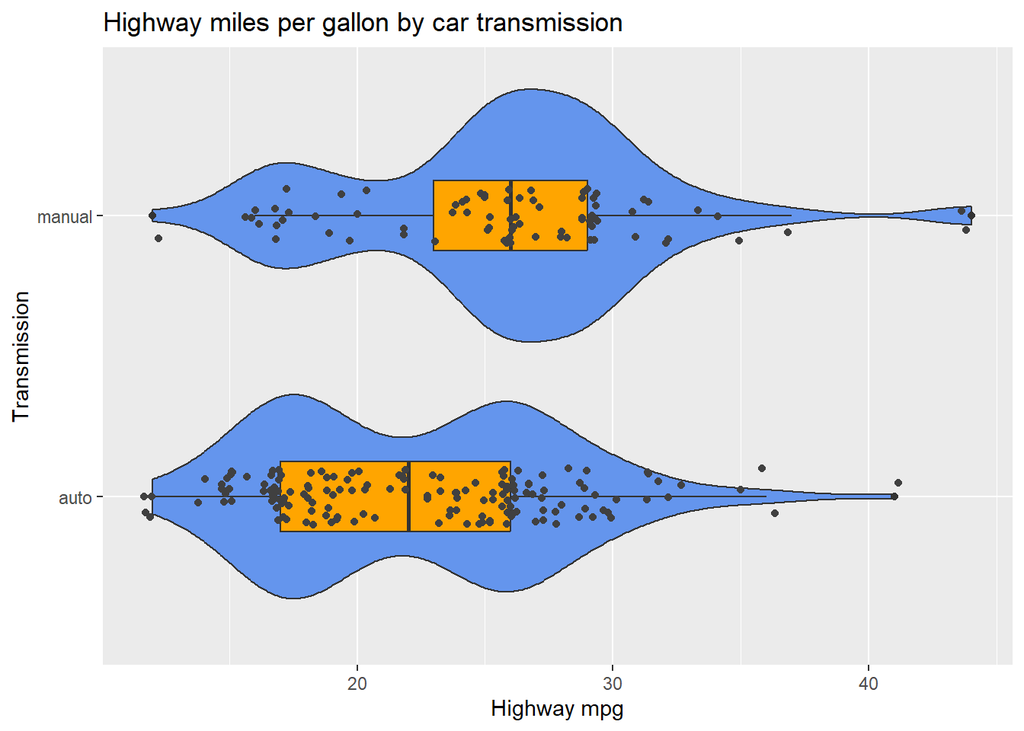

```r
# Specify the data and mapping
ggplot(data=mpg2, mapping=aes(x=hwy, y=trans)) +

  # Draw violin plots
  geom_violin(fill="cornflowerblue") +

  # Draw boxplots
  geom_boxplot(width=0.25, fill="orange") +

  # Draw jitter points
  geom_jitter(height=0.1, col="grey25") +

  # Change x and y-axes labels
  labs(x="Highway mpg", y="Transmission",
       title="Highway miles per gallon by car transmission")
```

### Grouped kernel density plots

The kernel density plots can also be used to compare distributions between groups. This can be done by adding the `fill` argument in the `aes()` mapping to use different fill colors for different groups.

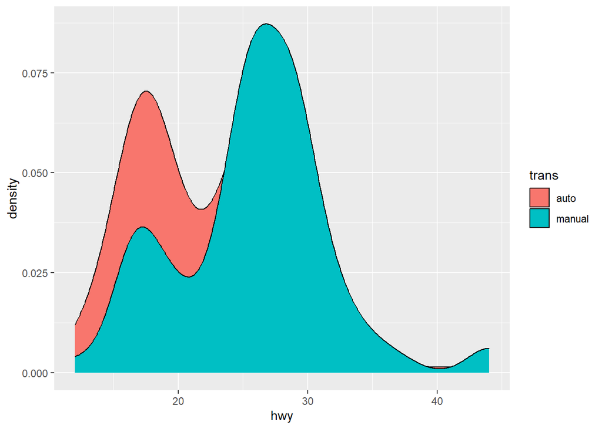

```r
# Specify the data and mapping, fill the density accoring to trans
ggplot(data=mpg2, mapping=aes(x=hwy, fill=trans)) +

  # Draw kernel density plots
  geom_density()
```

However, as we have seen in the plot above, the manual transmission kernel density covers the automatic transmission, making it difficult to see its kernel density. We can overcome this by specifying the transparency of the color by using `alpha` argument in the `geom_density()`. The alpha values control the transparency with value 1 for no transparency and value 0 for total transparency.

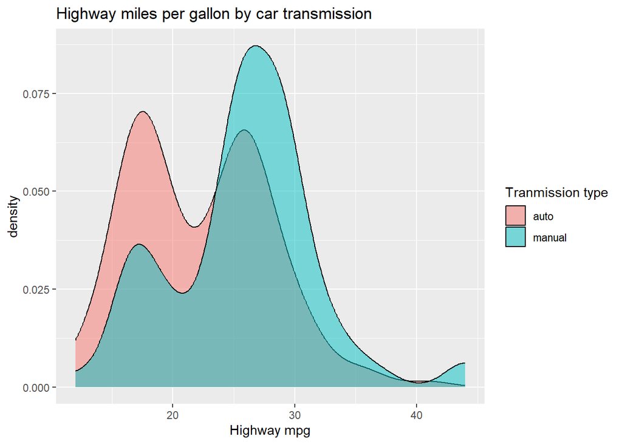

```r
# Specify the data and mapping, fill the density accoring to trans
ggplot(data=mpg2, mapping=aes(x=hwy, fill=trans)) +

  # Draw kernel density plots, change the density to be 50% transparent
  geom_density(alpha=0.5) +

  # Change x-axis label, legend, title
  labs(x="Highway mpg", fill="Tranmission type",
       title="Highway miles per gallon by car transmission")
```

### Ridgeline plots

The ridgeline plot is similar to the kernel density plot with vertical facetting. It is used to compare the distribution of a quantitative variable over different groups by plotting the kernel density for different groups alligned vertically.

However, it is not available in the `ggplot2` package but can be downloaded and used using `ggridges` package.

```r
# Install the package, run once per R version
install.packages("ggridges")

# Load the package, run once per R session
library(ggridges)
```

To draw the ridgeline plot, we can use `geom_density_ridges()` in the `ggridges` package. We also have to specify the `y` argument in the `aes()` mapping for the group variable.

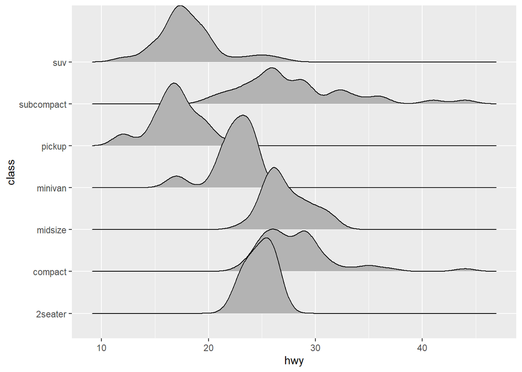

```r
# Specify the data and mapping
ggplot(data=mpg2, mapping=aes(x=hwy, y=class)) +

  # Draw ridgelines
  geom_density_ridges()
```

If we want to have different colors for the different classes, we can use the `fill` argument in the `aes()` mapping. But if the `y` and `fill` argument refers to the same thing, we might want to remove the legend by using `theme(legend.position="none")`.

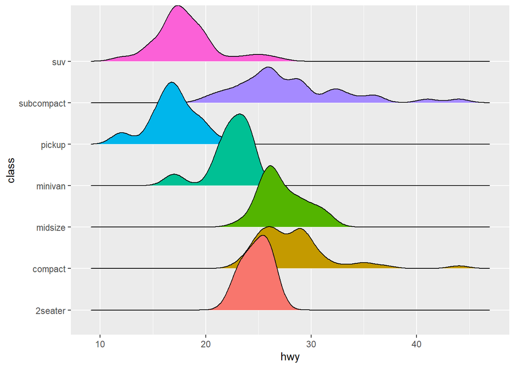

```r
# Specify the data and mapping, fill the density by class
ggplot(data=mpg2, mapping=aes(x=hwy, y=class, fill=class)) +

  # Draw ridgelines
  geom_density_ridges() +

  # Remove legend
  theme(legend.position="none")
```

The `fill` argument can also be used for a different grouping variable.

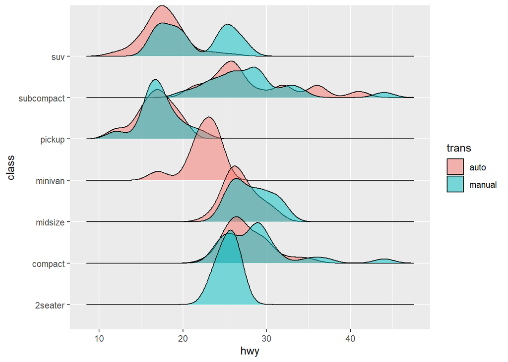

```r
# Specify the data and mapping, fill the density by trans
ggplot(data=mpg2, mapping=aes(x=hwy, y=class, fill=trans)) +

  # Draw ridgelines, use 50% transparency
  geom_density_ridges(alpha=0.5)
```

## Comparing Values between Groups

So far, we have used the raw data when creating plots and visuals to compare between different groups. A different way to make group comparison is by comparing the summary statistics, for example the average (or the mean), the variance, the median, and so on, for different groups. This is useful when we have quantitative data.

### Bar charts on summary statistics

We can draw the bar charts for the group mean by using `stat="summary"` argument in the `geom_bar()`. To demonstrate, we will first calculate the group mean using `summarize` and `group_by` in the `dplyr` package.

```r
# From mpg2 ..
mean_hwy <- mpg2 %>%

  # .. group data by class ..
  group_by(class) %>%

  # .. summarize by mean/average of hwy
  summarize(mean_value=mean(hwy))

# Print mean_hwy
mean_hwy
```

```
## # A tibble: 7 × 2
##   class      mean_value
##   <chr>           <dbl>
## 1 2seater          24.8
## 2 compact          28.3
## 3 midsize          27.3
## 4 minivan          22.4
## 5 pickup           16.9
## 6 subcompact       28.1
## 7 suv              18.1
```

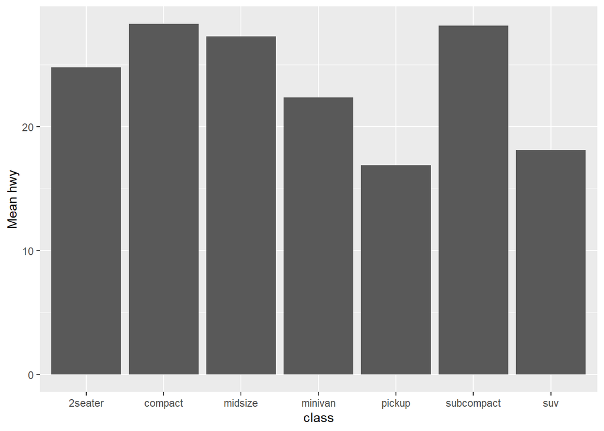

```r
# Specify the data and mapping
ggplot(data=mpg2, mapping=aes(x=class, y=hwy)) +

  # Draw var chart using mean/average
  geom_bar(stat="summary") +

  # Change y-axis label
  labs(y="Mean hwy")
```

If we want to use a different summarization other than the mean, we can first calculate the summary statistics and then plot the bar chart using the new data frame. Then, use the new data frame and the calculated value as the `y` argument in the `aes()` mapping, and use `geom_col()` or `geom_bar()` with the `stat="identity"` option.

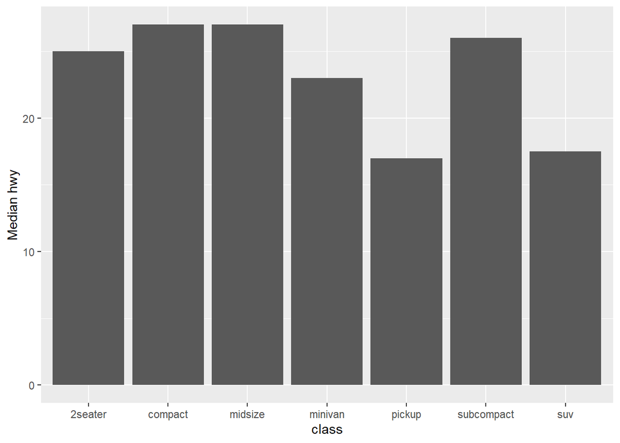

```r
# Create a new data frame that calculates median for each class
median_hwy <- mpg2 %>%
  group_by(class) %>%
  summarize(median_value=median(hwy))

# Specify the data and mapping, use median value as y
ggplot(data=median_hwy, mapping=aes(x=class, y=median_value)) +

  # Draw bar chart, use y values as is
  geom_col() +
  # OR
  # geom_bar(stat="identity")

  # Change y-axis label
  labs(y="Median hwy")
```

### Cleveland dot plot

Cleveland dot plot is a simple visual that is used to compare a value for different groups or categories. It can be plotted using `geom_point()` after specifying the respective `x` and `y` for the `aes()` mapping.

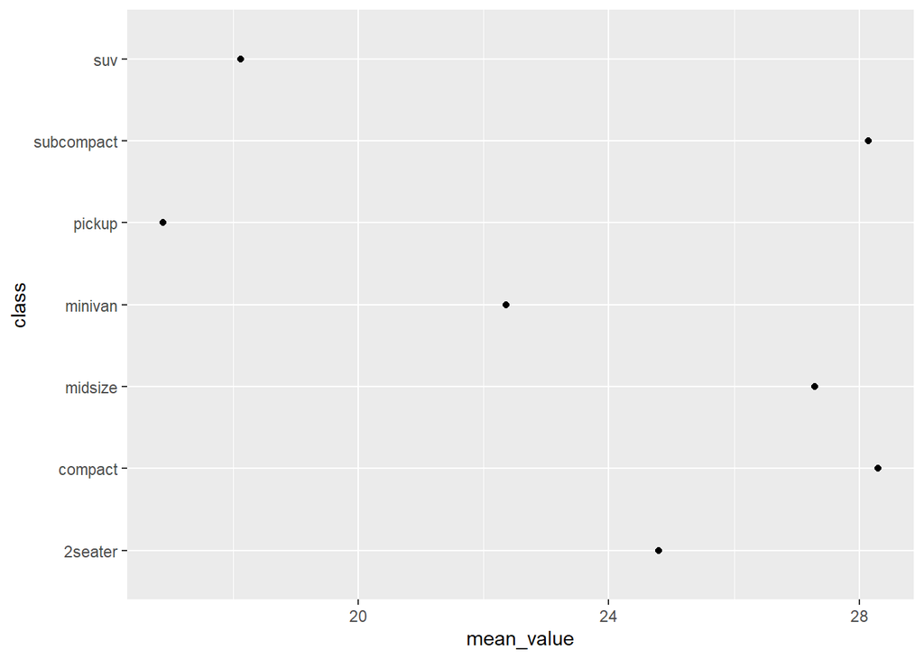

```r
# Create a new data frame that calculates mean/average for each class
mean_hwy <- mpg2 %>%
  group_by(class) %>%
  summarize(mean_value=mean(hwy))

# Specify the data and mapping
ggplot(data=mean_hwy, mapping=aes(x=mean_value, y=class)) +

  # Draw dots/points
  geom_point()
```

The plot above while useful, is not good as it can be further improved by reordering the categories or classes in increasing or decreasing order with respect to the value. We can do this by using the `reorder()` function for the `y` argument in `aes()` mapping.

Next, we can make the chart more attractive by removing the background and grid, and adding a line segment from the class to the point. To add line segment, we will use `geom_segment()` and we need to specify the starting x and y position using `x` and `y` arguments, as well as the ending x and y position using `xend` and `yend` arguments. We can also change the title, x and y-axes labels, and the color of the point.

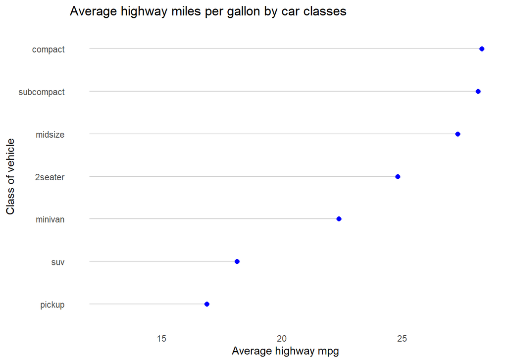

```r
# Specify the data and mapping, y is class reordered according to mean
ggplot(data=mean_hwy, mapping=aes(x=mean_value,
                                  y=reorder(class, mean_value))) +

  # Draw line segments
  geom_segment(mapping=aes(x=12,
                           xend=mean_value,
                           y=reorder(class, mean_value),
                           yend=reorder(class, mean_value)),
               color="lightgrey")+

  # Draw dots/points, make it blue and double its size
  geom_point(color="blue", size=2) +

  # Use minimal theme
  theme_minimal() +

  # Remove horizontal and vertical grids
  theme(panel.grid.major = element_blank(),
        panel.grid.minor = element_blank()) +

  # Change x and y-axes labels, and title
  labs(x="Average highway mpg", y="Class of vehicle",
       title="Average highway miles per gallon by car classes")
```

### Heatmap

Heatmap is a visual that is formed by forming a grid of rectangles where the color of the rectangle represent the value of interest. The value of interest can be anything including count, average, or correlation between the x and y variables. It can even be a third variable. For this visual, we will be using the `gapminder` dataset from `gapminder` package.

To draw a heatmap, we can use `geom_tile()` function with the `fill` option in the `aes()` mapping is specified to the value of interest.

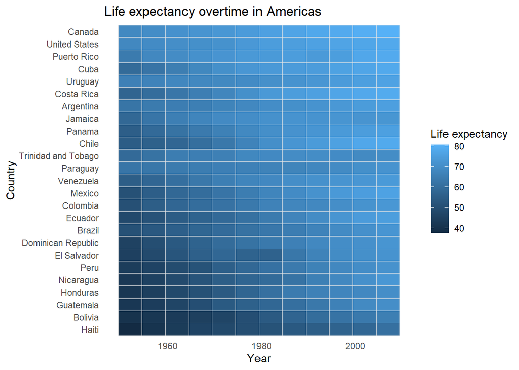

```r
library(gapminder)

# Filter data for Americas only
newdata <- filter(gapminder, continent=="Americas")

# Specify the data and mapping
ggplot(data=newdata, mapping = aes(x=year, y=reorder(country,lifeExp),
                                   fill=lifeExp)) +

  # Draw tiles with the border color option
  geom_tile(color="grey90") +

  # Remove background
  theme_minimal() +

  # Remove grids
  theme(panel.grid.major = element_blank(),
        panel.grid.minor = element_blank()) +

  # Change the axes, legend, and title
  labs(x="Year", y="Country", fill="Life expectancy",
       title="Life expectancy overtime in Americas")
```

We can see from the plot that Canada and US in general have the highest life expectancy, whereas Haiti and Bolivia have the lowest life expectancy in Americas continent. We also note that overtime, the life expectancy improves overall for all countries.

## Conclusion

In this topic, we have explored some charts and visuals that can be used to make group comparison including using facets, different form of bar charts, and grouped boxplots, violin plots, and kernel plots. We have also discussed on plotting summary statistics or a single value to compare between groups. These visuals are not all there are for showing the similarity or differences between groups, but you should be able to get some idea of it.